Reusable analytics framework

# One pipeline, every dataset.

AI2Analytics is a Python and R framework for analysts and data scientists who keep rebuilding the same analytical pipeline against new data. Once per region, once per business unit, once per customer segment, once per brand. It separates pipeline *logic* from *data shape*, so you write the model once and configure it many times. The reference templates cover entity segmentation, market mix modelling, and a panel-level allocation optimiser, with an optional LLM-assisted layer for onboarding new datasets.

The included demos use pharmaceutical promotional data because that is the domain the author works in, but the primitives are transportable across consumer goods, software, retail, financial services, and any other setting with panel-structured response data and a need to fit the same model to many slices of it.

Reusable templates

Segmentation, MMM, and call optimisation, all driven by a single typed config.

Plain DataFrames in

Pipelines accept pandas / tibbles directly. Spark optional, never required.

Knowledge that compounds

Every run logs config, data profile, and metrics. New runs draw on past ones.

Available in two languages

Native Python and R packages with the same API shape and verified numerical agreement.

## Capabilities

Each template is a thin layer over standard libraries (scikit-learn, glmnet, PuLP), wrapped in a config-first API so the same code runs across schemas. Outputs are plain DataFrames you can keep working with.

### Entity segmentation

`SegmentationPipeline` · KMeans, hierarchical, or auto-method with optional auto-k.

Cluster any entity table by any numeric features. Handles missing values (median/mean/zero/drop), normalisation (standard / minmax / robust), and optional PCA. Returns a tidy assignment table plus per-segment feature profiles and a silhouette score.

- Which HCPs are heavy IL-17 prescribers vs. mixed-class writers?
- Which accounts are low-volume but high-tier?
- Should we use 3, 4, or 5 segments — let the data decide?

```
from ai2analytics.templates.segmentation import (
    SegmentationConfig, SegmentationPipeline,
)

cfg = SegmentationConfig(
    col_entity_id   = "npi",
    feature_columns = ["IL_17_TRX_L12M", "IL_23_TRX_L12M"],
    n_segments      = 4,
    method          = "auto",   # picks kmeans vs hierarchical
    output_csv      = "segments.csv",
)
out = SegmentationPipeline().run(cfg, dataframes={"entity_data": hcps})
out.profiles    # per-segment feature means
out.assignments # one row per entity
```

### Market mix modelling

`MarketMixPipeline` · adstock + saturation + ridge / lasso / OLS, with contribution decomposition and response curves.

Geometric adstock per channel, choice of Hill or log saturation, optional positivity constraint. Reports R² and MAPE, decomposes weekly sales into base / channel / control contributions, and emits a per-channel response curve you can use for budget what-if analyses.

- How much of last quarter's sales did Digital actually drive?
- What's the marginal ROI of a $1 increase in TV?
- If we shifted 5 pp from Print to Digital, what happens?

```
from ai2analytics.templates.market_mix import (
    MarketMixConfig, MarketMixPipeline,
)

cfg = MarketMixConfig(
    col_date           = "WEEK_ENDING",
    col_response       = "SALES",
    media_columns      = ["TV_SPEND", "DIGITAL_SPEND", "PRINT_SPEND"],
    control_columns    = ["PRICE_INDEX", "DISTRIBUTION_PCT"],
    default_saturation = "log",
    model_type         = "ridge",
)
out = MarketMixPipeline().run(cfg, dataframes={"time_series": ts})
out.channel_summary  # spend, contribution, ROI, coefficient per channel
out.response_curves  # 50-pt grid per channel
```

### HCP call allocation

`DetailOptimizationPipeline` · probability + depth + look-alike models, then a PuLP LP under territory budget constraints.

- Given 80 calls per territory per quarter, who should each rep visit, and how often?
- Which non-target HCPs look like high-value writers (the look-alike score)?
- How does the planned plan compare to last cycle's actuals?

```
from ai2analytics.templates.detail_optimization import (
    DetailOptimizationConfig, DetailOptimizationPipeline,
)

cfg = DetailOptimizationConfig(
    drug_name      = "BRAND_X",
    il_rx_columns  = [("IL_17_TRX_L12M", "IL_17_DECILE"),
                      ("IL_23_TRX_L12M", "IL_23_DECILE")],
    team_a_budget_per_territory = 80,
    output_csv     = "call_plan.csv",
)
results = DetailOptimizationPipeline().run(
    cfg, dataframes={...}  # 7 input tables
)
results.portfolio  # one row per HCP x team
```

### Knowledge that accumulates

`DecisionStore` + `ContextStore` + `KnowledgeRetriever` · JSONL or Spark Delta backend.

Every pipeline run is logged: config, data profile, auto-detected vs. user-answered fields, adapter code, outcome metrics, free-form tags. A separate context store holds curated patterns ("US tables use `npi`", "BRIC quarterly performance must be aggregated to one row per account before clustering"). The retriever combines both into a structured block for prompt injection or human reference.

- What did we configure last quarter that worked?
- What's the standard column mapping for EU data?
- What adapter code patterns have we used for this template before?

```
from ai2analytics.knowledge import (
    DecisionStore, DecisionRecord, ContextStore, KnowledgeRetriever,
)

decisions = DecisionStore(backend="json", path="decisions.jsonl")
context   = ContextStore(backend="json", path="context.jsonl")

decisions.log(DecisionRecord(
    template_name="segmentation",
    config_dict={"col_entity_id": "npi", "n_segments": 4},
    outcome_metrics={"silhouette_score": 0.61},
    tags=["us", "hcp", "q4-2025"],
))

retriever = KnowledgeRetriever(decisions, context)
print(retriever.retrieve_for_analysis(
    template_name="segmentation", scope={"region": "us"},
))
```

### Bundled synthetic datasets

Three generators produce realistic fake commercial datasets matching the schemas the templates expect. No PII, deterministic given a seed, everything in memory by default.

| Generator | Market style | Cadence | Tables produced |
| --- | --- | --- | --- |
| `us_hcp.generate_all()` | US | Weekly | HCP reference, weekly activity, calls, two team alignments, portfolio decile, priority targets |
| `eu_account.generate_all()` | EU | Monthly | Account reference, monthly performance, multi-channel visits, KAM & medical alignment |
| `bric.generate_all()` | BRIC | Quarterly | Account master, quarterly performance, engagement, sales alignment |

### LLM-assisted onboarding (Python)

For a brand-new dataset where you don't yet know the column mappings, `AnalyticsSession` surveys your Spark catalog, profiles each table, asks an LLM to match discovered columns to the template's declared requirements, and generates adapter code where shapes don't line up. Conversation is structured around exact config field names, so anything the LLM doesn't auto-fill becomes a targeted question.

```
from ai2analytics import AnalyticsSession
session = AnalyticsSession(spark=spark, llm_endpoint="your-endpoint")
session.discover(schemas=["commercial_data"], prompt="Optimize HCP call allocation")
session.show_questions()       # auto-detected vs. needs-answer
session.answer({"drug_name": "BRAND_X", "output_csv": "/dbfs/.../plan.csv"})
session.generate_adapter()     # LLM writes preprocessing code
session.run_adapter()          # executes; auto-retries with LLM fix on error
session.run()                  # runs the full pipeline
```

## Demo notebooks

Five executable Jupyter notebooks under `demos/notebooks/`. Each opens with a self-installing setup cell — one click in Colab, no checkout required, all synthetic data bundled in the package.

Hello world

### 00 · Quickstart

**Dataset:** 5,000 synthetic US HCPs · **Time to run:** <30s

Five cells, end-to-end: generate synthetic prescribers, cluster them on two Rx-volume features, inspect the resulting segments, and view a PCA scatter. The shortest-possible "convince me in 60 seconds" tour.

**Result:** 4 segments on 5,000 HCPs in <1s. Silhouette 0.6142 — clean separation between heavy IL-17 writers (mean 35 Rx) and the mixed group (16 IL-17, 18 IL-23).

[Open in Colab](https://colab.research.google.com/github/jamesyoung93/AI2Analytics/blob/master/demos/notebooks/00_quickstart.ipynb)

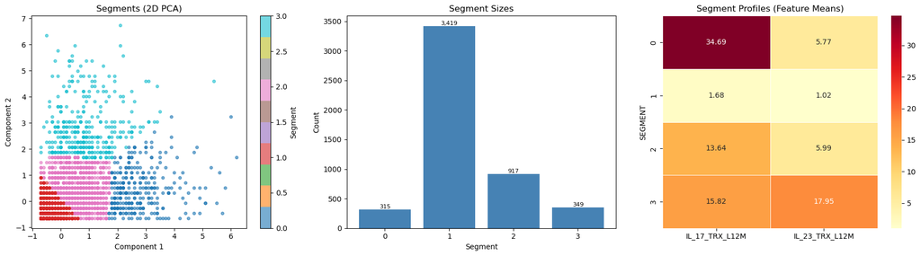

PCA scatter plus segment sizes — output of `pipeline.dashboard()`.

Schema portability

### 01 · One pipeline, three regions

**Dataset:** US HCPs (5,000), EU accounts (3,000), BRIC accounts (2,000) · **Time:** ~30s

The thesis demo. The *identical* `SegmentationPipeline` class clusters US individual prescribers, EU institutional accounts, and a joined BRIC quarterly view — three different schemas, three different entity types — with all differences absorbed into `SegmentationConfig`. The `auto` method picks KMeans for US/EU and hierarchical for BRIC.

**Result:** US silhouette 0.61 (kmeans), EU 0.57 (kmeans), BRIC 0.52 (hierarchical) — all three in a healthy range with one pipeline class.

[Open in Colab](https://colab.research.google.com/github/jamesyoung93/AI2Analytics/blob/master/demos/notebooks/01_one_template_three_regions.ipynb)

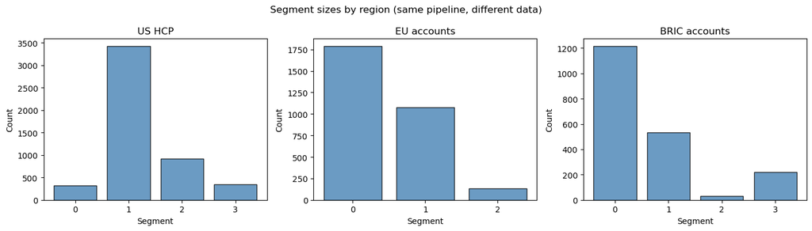

Segment sizes by region — same pipeline, three schemas.

Actionable analytics

### 02 · MMM with budget reallocation

**Dataset:** 156 weeks of synthetic media + sales · **Time:** ~10s

Fits a market mix model on three years of weekly TV / Digital / Print spend, then runs a small reallocation grid using *only* quantities the pipeline already returns: per-channel coefficients and adstock decay from `channel_summary`, saturation shape from `response_curves`. No bespoke math — the answer falls out of the model.

**Result:** Model reaches R² 0.81, MAPE 5.05%. Reallocation search recommends moving Digital share from 27.5% to 25% and TV from 48.4% to 55% — **+~48 sales/yr at the same total spend**.

[Open in Colab](https://colab.research.google.com/github/jamesyoung93/AI2Analytics/blob/master/demos/notebooks/02_market_mix_budget_reallocation.ipynb)

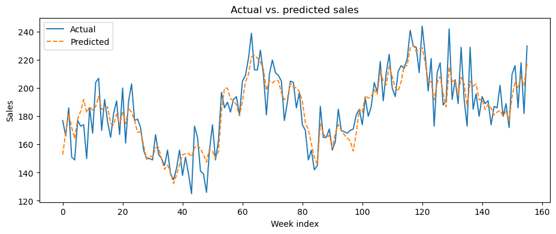

Actual (solid) vs. predicted (dashed) sales over 156 weeks.

End-to-end pipeline

### 03 · Call optimizer end-to-end

**Dataset:** 7-table synthetic US commercial dataset · **Time:** ~60s

The most ambitious demo. Runs the full `DetailOptimizationPipeline`: load → lag / rolling features → train probability + depth + look-alike models with walk-forward backtest → score every HCP at every call-count scenario → solve a PuLP linear programme under per-territory budgets and priority-target rules → long-format portfolio with audit columns. Plots calls per territory by team and the decile-uplift of the budget.

[Open in Colab](https://colab.research.google.com/github/jamesyoung93/AI2Analytics/blob/master/demos/notebooks/03_call_optimizer_endtoend.ipynb)

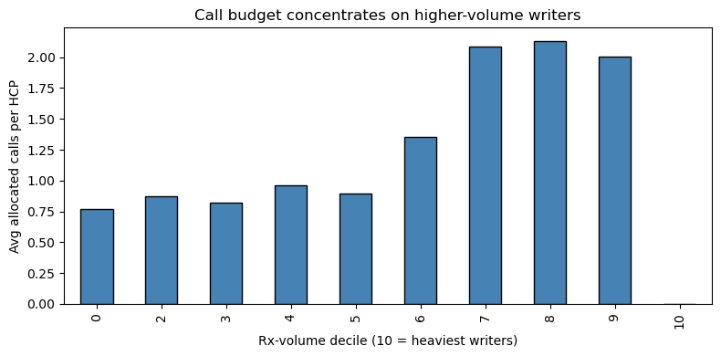

Average allocated calls per HCP by Rx-volume decile.

Operational learning

### 04 · Knowledge accumulates over runs

**Dataset:** Four simulated quarterly rollouts (US Q3, EU Q3, US Q4, BRIC Q4) · **Time:** <5s

Walks through the knowledge layer: log four pipeline runs into a JSONL `DecisionStore`, curate a handful of context entries, then call `KnowledgeRetriever.retrieve_for_analysis()` scoped to a fresh region. The retriever surfaces the BRIC-specific aggregation pattern that emerged from the one prior BRIC run — the kind of tribal knowledge that usually lives in one analyst's head.

**Result:** 4 logged runs + 4 curated patterns yield a region-aware knowledge block ready for an LLM prompt or a new analyst's first read.

[Open in Colab](https://colab.research.google.com/github/jamesyoung93/AI2Analytics/blob/master/demos/notebooks/04_knowledge_accumulates.ipynb)

4 runs

across US / EU / BRIC,  
4 curated context entries,  
fed into one retriever block.

## Use it from Python or R

Both packages are first-class citizens. The R port (`r-pkg/ai2analytics/`) uses idiomatic R6 + tibble — no Python interop required. Constructor names mirror the Python API, and the `dataframes = list(entity_data = df)` pattern is the same shape as Python's `dataframes={"entity_data": df}`.

| Capability | Python | R | Notes |
| --- | --- | --- | --- |
| Entity segmentation | ✓ | ✓ | Same constructor names, same options. |
| Market mix modelling | ✓ | ✓ | R uses `glmnet`; `alpha` argument is sklearn-equivalent. |
| Knowledge stores & retriever | ✓ | ✓ | JSONL backend in both. Spark Delta backend Python-only. |
| Synthetic datasets (US / EU / BRIC) | ✓ | ✓ | Native generators in each language; equivalent shape, different RNG. |
| HCP call optimisation | ✓ | — | Python only for now — the LP + RF stack is large; R port deferred. |
| LLM-assisted session | ✓ | — | Python only — recommend wiring `httr2`/`ellmer` at the application layer in R. |

**Numerical agreement.** The two implementations were tested on the same shared CSV running the same canonical Market Mix configuration: **R² agrees to within 0.003**, per-channel ROI to within 10%, and channel ranking is identical (TV > Digital > Print). A regression test in the R suite pins this so future changes can't drift unnoticed.

The R API for the same MMM looks like this:

```
library(ai2analytics)

cfg <- MarketMixConfig(
  col_date           = "WEEK_ENDING",
  col_response       = "SALES",
  media_columns      = c("TV_SPEND", "DIGITAL_SPEND", "PRINT_SPEND"),
  control_columns    = c("PRICE_INDEX", "DISTRIBUTION_PCT"),
  default_saturation = "log",
  model_type         = "ridge"
)

out <- MarketMixPipeline$new()$run(cfg, dataframes = list(time_series = ts))
out$channel_summary   # tibble with spend, contribution, ROI per channel
```

Four RMarkdown vignettes mirror the first, second, third, and fifth Python notebooks. Render any of them with `rmarkdown::render("vignettes/a_quickstart.Rmd")`.

## Get started

Install one of the two packages, generate a bundled dataset, and run a pipeline. Both code paths fit on one screen.

### Python

```
pip install git+https://github.com/jamesyoung93/AI2Analytics.git
```

```
from ai2analytics.datasets import us_hcp
from ai2analytics.templates.segmentation import (
    SegmentationConfig, SegmentationPipeline,
)

dfs = us_hcp.generate_all(seed=42)
cfg = SegmentationConfig(
    col_entity_id   = "npi",
    feature_columns = ["IL_17_TRX_L12M", "IL_23_TRX_L12M"],
    n_segments      = 4,
    output_csv      = "segments.csv",
)
out = SegmentationPipeline().run(
    cfg, dataframes={"entity_data": dfs["hcp_reference"]}
)
out.profiles  # 4 segments x 2 features
```

### R

```
devtools::install_github("jamesyoung93/AI2Analytics",
                         subdir = "r-pkg/ai2analytics")
```

```
library(ai2analytics)

dfs <- generate_us_hcp(seed = 42)
cfg <- SegmentationConfig(
  col_entity_id   = "npi",
  feature_columns = c("IL_17_TRX_L12M", "IL_23_TRX_L12M"),
  n_segments      = 4,
  output_csv      = "segments.csv"
)
out <- SegmentationPipeline$new()$run(
  cfg, dataframes = list(entity_data = dfs$hcp_reference)
)
out$profiles  # tibble: 4 segments x 2 features
```

**Where to go next.** If you have data and want to try the AI-assisted workflow, see `AnalyticsSession` in the README. If you want to add a new template, subclass `BaseTemplate` and declare `required_tables` with `config_field` links — the discovery and conversation layers will wire your data automatically.